# BIOSTAT 620 Lab 3

Kyoka Ono

2026-01-29

```r
library(dplyr)
```

### 1. Read in the data

```r
met <- read.csv("/Users/kyokaono/Desktop/BIOSTAT620 /met_all (1).gz")
```

### 2. Check the dimensions, headers, footers

- 2377343 rows
- 30 columns

```r
dim(met)
```

```
## [1] 2377343      30
```

### 3. Take a look at all the variables (hint: use the str funcion)

```r
str(met)
```

```
## 'data.frame':    2377343 obs. of  30 variables:
##  $ USAFID           : int  690150 690150 690150 690150 690150 690150 690150 690150 690150 690150 ...
##  $ WBAN             : int  93121 93121 93121 93121 93121 93121 93121 93121 93121 93121 ...
##  $ year             : int  2019 2019 2019 2019 2019 2019 2019 2019 2019 2019 ...
##  $ month            : int  8 8 8 8 8 8 8 8 8 8 ...
##  $ day              : int  1 1 1 1 1 1 1 1 1 1 ...
##  $ hour             : int  0 1 2 3 4 5 6 7 8 9 ...
##  $ min              : int  56 56 56 56 56 56 56 56 56 56 ...
##  $ lat              : num  34.3 34.3 34.3 34.3 34.3 34.3 34.3 34.3 34.3 34.3 ...
##  $ lon              : num  -116 -116 -116 -116 -116 ...
##  $ elev             : int  696 696 696 696 696 696 696 696 696 696 ...
##  $ wind.dir         : int  220 230 230 210 120 NA 320 10 320 350 ...
##  $ wind.dir.qc      : chr  "5" "5" "5" "5" ...
##  $ wind.type.code   : chr  "N" "N" "N" "N" ...
##  $ wind.sp          : num  5.7 8.2 6.7 5.1 2.1 0 1.5 2.1 2.6 1.5 ...
```

[output cut: 16 more lines]

### 4. Take a closer look at the key variales (year, day, hour, temp, elev, wind.sp). Hint: use table and/or summary.

```r
year <- met["year"]
table(year)
```

```
## year
##    2019
## 2377343
```

```r
day <- met["day"]
table("day")
```

```
##
## day
##   1
```

```r
hour <- met["hour"]
table(hour)
```

```
## hour
##      0      1      2      3      4      5      6      7      8      9     10
##  99434  93482  93770  96703 110504 112128 106235 101985 100310 102915 101880
##     11     12     13     14     15     16     17     18     19     20     21
## 100470 103605  97004  96507  97635  94942  94184 100179  94604  94928  96070
##     22     23
##  94046  93823
```

```r
summary(hour)
```

```
##       hour
##  Min.   : 0.00
##  1st Qu.: 5.00
##  Median :11.00
##  Mean   :11.34
##  3rd Qu.:17.00
##  Max.   :23.00
```

```r
temp <- met["temp"]
summary(temp)
```

```
##       temp
##  Min.   :-40.00
##  1st Qu.: 19.60
##  Median : 23.50
##  Mean   : 23.59
##  3rd Qu.: 27.80
##  Max.   : 56.00
##  NA's   :60089
```

```r
elev <- met["elev"]
summary(elev)
```

```
##       elev
##  Min.   : -13.0
##  1st Qu.: 101.0
##  Median : 252.0
##  Mean   : 415.8
##  3rd Qu.: 400.0
##  Max.   :9999.0
```

```r
wind.sp <- met["wind.sp"]
summary(wind.sp)
```

```
##     wind.sp
##  Min.   : 0.000
##  1st Qu.: 0.000
##  Median : 2.100
##  Mean   : 2.459
##  3rd Qu.: 3.600
##  Max.   :36.000
##  NA's   :79693
```

```r
# checking missing data for the elevation
sum(met$elev == 9999.0)
```

```
## [1] 710
```

```r
# replacing 9999.0 elevation with NAs
met$elev[which(met$elev == 9999.0)] <- NA
```

```r
sum(met$elev == 9999.0, na.rm = TRUE)
```

```
## [1] 0
```

```r
# checking the highest weather station (4113)
max(met$elev, na.rm = TRUE)
```

```
## [1] 4113
```

```r
# checking temperature data with -40C
sum(met$temp == -40.0, na.rm = TRUE)
```

```
## [1] 36
```

```r
# Replacing -40.0 with NA
met$temp[which(met$temp == -40.0)] <- NA
```

```r
sum(met$temp == -40.0, na.rm = TRUE)
```

```
## [1] 0
```

```r
# the new lowest temperature
min(met$temp, na.rm = TRUE)
```

```
## [1] -17.2
```

### 5. Check the data against an extrnal data source.

Validate that the total range of elevation in the data make sense. Also, we should check the suspicious -17.2C temperature value (where is it located?).

```r
# The range of elevation makes sense. According to Google, it is positive if it is above the sea level, and negative if it is below the sea level.
summary(met$elev)
```

```
##    Min. 1st Qu.  Median    Mean 3rd Qu.    Max.    NA's
##     -13     101     252     413     400    4113     710
```

```r
# According to Google map, the location is Ellicott, Colorado. The average temperature during August seems to be higher than what is represented on the data.
head(met %>% filter(temp == -17.2))
```

```
##   USAFID WBAN year month day hour min    lat    lon elev wind.dir wind.dir.qc
## 1 722817 3068 2019     8   1    0  56 38.767 -104.3 1838      190           5
## 2 722817 3068 2019     8   1    1  56 38.767 -104.3 1838      180           5
## 3 722817 3068 2019     8   3   11  56 38.767 -104.3 1838       NA           9
## 4 722817 3068 2019     8   3   12  56 38.767 -104.3 1838       NA           9
## 5 722817 3068 2019     8   6   21  56 38.767 -104.3 1838      280           5
## 6 722817 3068 2019     8   6   22  56 38.767 -104.3 1838      240           5
##   wind.type.code wind.sp wind.sp.qc ceiling.ht ceiling.ht.qc ceiling.ht.method
## 1              N     7.2          5         NA             9                 9
## 2              N     7.7          5         NA             9                 9
## 3              C     0.0          5         NA             9                 9
## 4              C     0.0          5         NA             9                 9
## 5              N     2.6          5         NA             9                 9
## 6              N     7.7          5         NA             9                 9
##   sky.cond vis.dist vis.dist.qc vis.var vis.var.qc  temp temp.qc dew.point
## 1        N       NA           9       N          5 -17.2       5        NA
## 2        N       NA           9       N          5 -17.2       5        NA
## 3        N       NA           9       N          5 -17.2       5        NA
## 4        N       NA           9       N          5 -17.2       5        NA
## 5        N       NA           9       N          5 -17.2       5        NA
## 6        N       NA           9       N          5 -17.2       5        NA
##   dew.point.qc atm.press atm.press.qc rh
## 1            9        NA            9 NA
## 2            9        NA            9 NA
## 3            9        NA            9 NA
## 4            9        NA            9 NA
## 5            9        NA            9 NA
## 6            9        NA            9 NA
```

### 6. Calculate summary statistics

Remember to keep the initial question in mind. We want to pick out the weather station with maximum elevation and examine its windspeed and temperature.

Some ideas: select the weather station with maximum elevation; within this station, look at the correlation between temperature and wind speed. Also, look at the correlation between (temp and wind.sp) and (hour and day) (four total pairwise correlations).

```r
max_elev_data <- met %>% filter(elev == 4113, !is.na(temp), !is.na(wind.sp))
head(max_elev_data)
```

```
##   USAFID WBAN year month day hour min  lat      lon elev wind.dir wind.dir.qc
## 1 720385  419 2019     8   1    0  36 39.8 -105.766 4113      170           5
## 2 720385  419 2019     8   1    0  54 39.8 -105.766 4113      100           5
## 3 720385  419 2019     8   1    1  12 39.8 -105.766 4113       90           5
## 4 720385  419 2019     8   1    1  35 39.8 -105.766 4113      110           5
## 5 720385  419 2019     8   1    1  53 39.8 -105.766 4113      120           5
## 6 720385  419 2019     8   1    2  12 39.8 -105.766 4113      120           5
##   wind.type.code wind.sp wind.sp.qc ceiling.ht ceiling.ht.qc ceiling.ht.method
## 1              N     8.8          5       1372             5                 M
## 2              N     2.6          5       1372             5                 M
## 3              N     3.1          5       1981             5                 M
## 4              N     4.1          5       2134             5                 M
## 5              N     4.6          5       2134             5                 M
## 6              N     6.2          5      22000             5                 9
##   sky.cond vis.dist vis.dist.qc vis.var vis.var.qc temp temp.qc dew.point
## 1        N       NA           9       N          5    9       5         1
## 2        N       NA           9       N          5    9       5         1
## 3        N       NA           9       N          5    9       5         2
## 4        N       NA           9       N          5    9       5         2
## 5        N       NA           9       N          5    9       5         2
## 6        N       NA           9       N          5    9       5         2
##   dew.point.qc atm.press atm.press.qc       rh
## 1            5        NA            9 57.61039
## 2            5        NA            9 57.61039
## 3            5        NA            9 61.85243
## 4            5        NA            9 61.85243
## 5            5        NA            9 61.85243
## 6            5        NA            9 61.85243
```

```r
# temperature and windspeed
cor(max_elev_data$temp, max_elev_data$wind.sp)
```

```
## [1] -0.09373843
```

```r
# temperature and hour
cor(max_elev_data$temp, max_elev_data$hour)
```

```
## [1] 0.4356801
```

```r
# temperature and day
cor(max_elev_data$temp, max_elev_data$day)
```

```
## [1] -0.006130763
```

```r
# wind.sp and hour
cor(max_elev_data$wind.sp, max_elev_data$hour)
```

```
## [1] 0.08807315
```

```r
# wind.sp and day
cor(max_elev_data$wind.sp, max_elev_data$day)
```

```
## [1] 0.3643079
```

### 7. Exploratory graphs

We should look at the distributions of all of the key variables to make sure there are no remaining issues with the data. Hint: using the hist function, make histograms of the elev, temp, and wind.sp variables.

(in hist(), it ignores NA values)

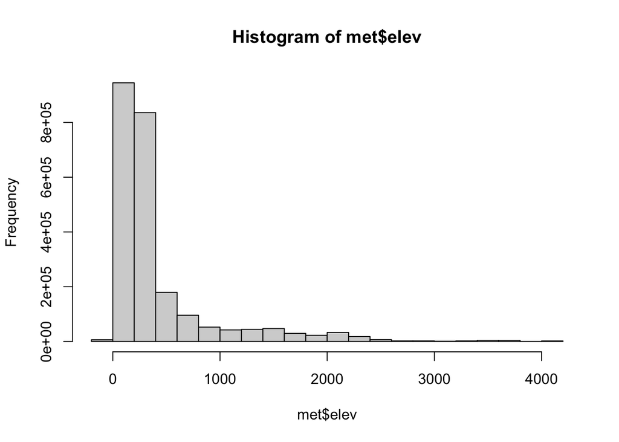

```r
hist(met$elev)
```

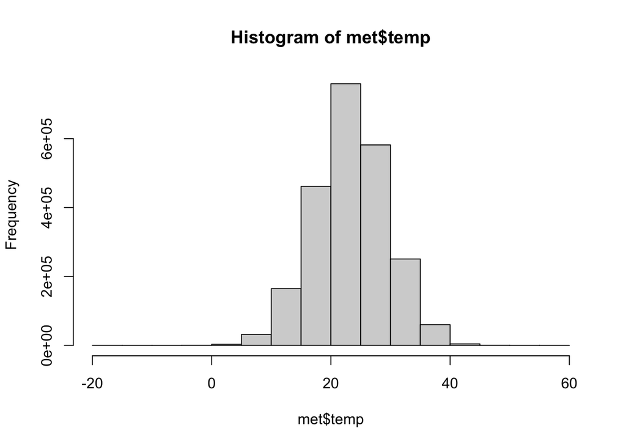

```r
hist(met$temp)
```

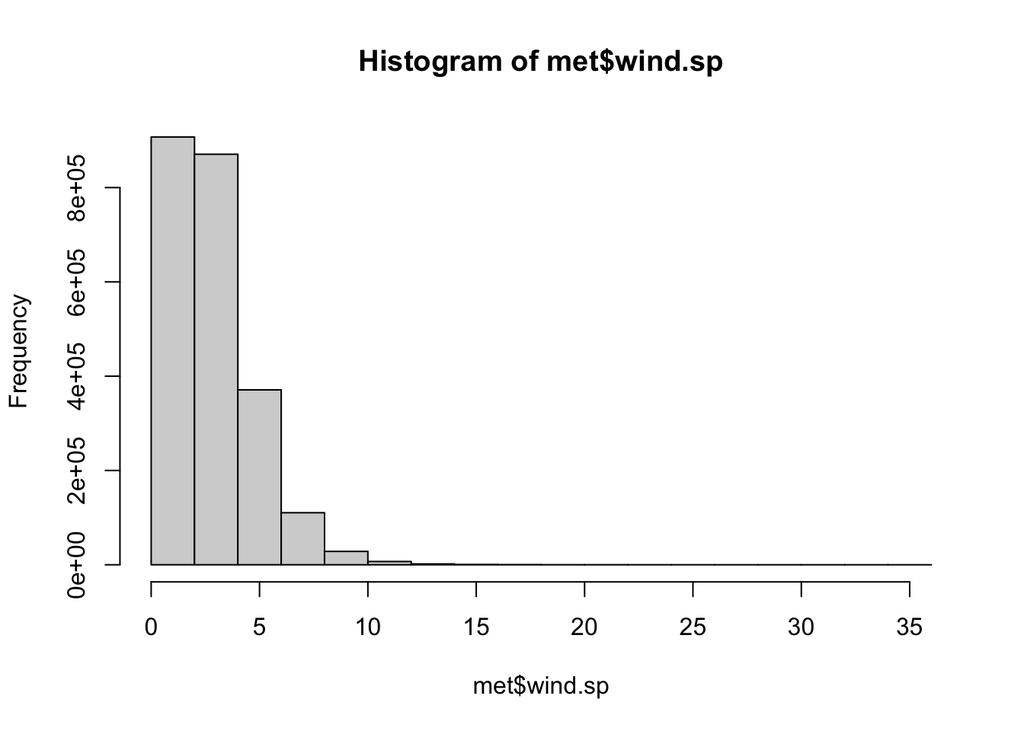

```r
hist(met$wind.sp)
```

```r
# Look at where the weather station with highest elevation is located
library(leaflet)
leaflet(max_elev_data) %>%
  addProviderTiles('OpenStreetMap') %>%
  addCircles(lat=~lat,lng=~lon, opacity=1, fillOpacity=1, radius=100)
```

[interactive chart not shown]

```r
# Look at the time series of temperature and wind speed at this location. For this we will need to create a date-time variable for the x-axis
library(lubridate)
max_elev_data$date <- with(max_elev_data, ymd_h(paste(year, month, day, hour, sep= ' ')))
summary(max_elev_data$date)
```

```
##                  Min.               1st Qu.                Median
## "2019-08-01 00:00:00" "2019-08-08 06:00:00" "2019-08-16 17:00:00"
##                  Mean               3rd Qu.                  Max.
## "2019-08-16 12:13:41" "2019-08-24 13:00:00" "2019-08-31 22:00:00"
```

```r
max_elev_data <- max_elev_data[order(max_elev_data$date), ]
head(max_elev_data)
```

```
##   USAFID WBAN year month day hour min  lat      lon elev wind.dir wind.dir.qc
## 1 720385  419 2019     8   1    0  36 39.8 -105.766 4113      170           5
## 2 720385  419 2019     8   1    0  54 39.8 -105.766 4113      100           5
## 3 720385  419 2019     8   1    1  12 39.8 -105.766 4113       90           5
## 4 720385  419 2019     8   1    1  35 39.8 -105.766 4113      110           5
## 5 720385  419 2019     8   1    1  53 39.8 -105.766 4113      120           5
## 6 720385  419 2019     8   1    2  12 39.8 -105.766 4113      120           5
##   wind.type.code wind.sp wind.sp.qc ceiling.ht ceiling.ht.qc ceiling.ht.method
## 1              N     8.8          5       1372             5                 M
## 2              N     2.6          5       1372             5                 M
## 3              N     3.1          5       1981             5                 M
## 4              N     4.1          5       2134             5                 M
## 5              N     4.6          5       2134             5                 M
## 6              N     6.2          5      22000             5                 9
##   sky.cond vis.dist vis.dist.qc vis.var vis.var.qc temp temp.qc dew.point
## 1        N       NA           9       N          5    9       5         1
## 2        N       NA           9       N          5    9       5         1
## 3        N       NA           9       N          5    9       5         2
## 4        N       NA           9       N          5    9       5         2
## 5        N       NA           9       N          5    9       5         2
## 6        N       NA           9       N          5    9       5         2
##   dew.point.qc atm.press atm.press.qc       rh                date
## 1            5        NA            9 57.61039 2019-08-01 00:00:00
## 2            5        NA            9 57.61039 2019-08-01 00:00:00
## 3            5        NA            9 61.85243 2019-08-01 01:00:00
## 4            5        NA            9 61.85243 2019-08-01 01:00:00
## 5            5        NA            9 61.85243 2019-08-01 01:00:00
## 6            5        NA            9 61.85243 2019-08-01 02:00:00
```

### 8. Ask questions

What is the correlation between wind.sp and elevation?

```r
new_data <- met %>% filter(!is.na(elev), !is.na(wind.sp))
cor(new_data$elev, new_data$wind.sp)
```

```
## [1] 0.1776027
```

Ans. There is a subtle positive correlation.